# NOAA Storm Database Analysis

Ana Baraldi

May 21, 2015

### Synopsis

Our dataset contains data from natural disasters across the USA between 1950 and 2011. Our focuses are going to be the most harmful events for human health and the impact in economics.

### Data Processing

Before we read our data, we are going to load the required libraries and set the global options for the data analysis.

```r
library(dplyr)
library(ggplot2)
library(knitr)
library(reshape2)
```

```r
opts_chunk$set(fig.align = "center")
options(scipen = 1, digits = 2)
```

Now we will start working with the data :)

```r
if(!file.exists("data.csv")) {
    download.file("https://d396qusza40orc.cloudfront.net/repdata%2Fdata%2FStormData.csv.bz2", destfile = "data.csv", method="curl")
}

data <- read.csv2("data.csv", sep = ",", stringsAsFactors = FALSE)
data <- mutate(data, FATALITIES = as.numeric(FATALITIES),
               INJURIES = as.numeric(INJURIES),
               PROPDMG = as.numeric(PROPDMG),
               CROPDMG = as.numeric(CROPDMG))
```

Before we begin our analysis, lets check what we have in our columns.

```r
names(data)
```

```
##  [1] "STATE__"    "BGN_DATE"   "BGN_TIME"   "TIME_ZONE"  "COUNTY"
##  [6] "COUNTYNAME" "STATE"      "EVTYPE"     "BGN_RANGE"  "BGN_AZI"
## [11] "BGN_LOCATI" "END_DATE"   "END_TIME"   "COUNTY_END" "COUNTYENDN"
## [16] "END_RANGE"  "END_AZI"    "END_LOCATI" "LENGTH"     "WIDTH"
## [21] "F"          "MAG"        "FATALITIES" "INJURIES"   "PROPDMG"
## [26] "PROPDMGEXP" "CROPDMG"    "CROPDMGEXP" "WFO"        "STATEOFFIC"
## [31] "ZONENAMES"  "LATITUDE"   "LONGITUDE"  "LATITUDE_E" "LONGITUDE_"
## [36] "REMARKS"    "REFNUM"
```

For our analysis the most important columns are going to be `EVTYPE` that tell us the storm event, `FATALITIES` and `INJURIES` to check the most harmful events and `PROPDMG` and `CROPDMG` to measure the economic consequences. Just to have a better view of our data, we are going to check the dataset dimension.

```r
dim <- dim(data)
```

As we can see our dataset has 902297 lines and 37 columns. It is a quite large dataset.

Now, lets begin our analysis!

### Results

In the first part of the analysis we are going to check the most harmful events, that’s why we will group our data by event type and then take the sum of the fatalities to see how many deaths have occurred between 1950 and 2011.

```r
grouped_fatalities <- group_by(data, EVTYPE) %>%
    summarise(fatalities=sum(FATALITIES)) %>%
    arrange(desc(fatalities))

total_fatality <- sum(grouped_fatalities$fatalities)

summary(grouped_fatalities)
```

```
##     EVTYPE            fatalities
##  Length:985         Min.   :   0
##  Class :character   1st Qu.:   0
##  Mode  :character   Median :   0
##                     Mean   :  15
##                     3rd Qu.:   0
##                     Max.   :5633
```

As we can see from the summary, we have 985 events types and at least 75% of them don’t count with any case of death. We had within all our data 15145 deaths. So let’s slice our data with the 15 events which had the biggest number of fatalities.

```r
sliced_fatalities <- slice(grouped_fatalities, 1:15)

total_sliced_fatalities <- sum(sliced_fatalities$fatalities)

sliced_fatalities
```

```
## Source: local data frame [15 x 2]
##
##               EVTYPE fatalities
## 1            TORNADO       5633
## 2     EXCESSIVE HEAT       1903
## 3        FLASH FLOOD        978
## 4               HEAT        937
## 5          LIGHTNING        816
## 6          TSTM WIND        504
## 7              FLOOD        470
## 8        RIP CURRENT        368
## 9          HIGH WIND        248
## 10         AVALANCHE        224
## 11      WINTER STORM        206
## 12      RIP CURRENTS        204
## 13         HEAT WAVE        172
## 14      EXTREME COLD        160
## 15 THUNDERSTORM WIND        133
```

Just to point out, our new sliced data have 12956 deaths, that represents 86% from our original data.

As we can see the event that has induced more deaths was `TORNADO` with 5633 fatalities, followed by `EXCESSIVE HEAT` with 1903 fatalities.

To make our analysis more complete we are going to consider also the `INJURIES` to check the most harmful storm events across the USA, but we are not going to do the same process again. As we have the 15 events that contains at least 86% of all deaths, we are going to check the same events for `INJURIES`.

```r
grouped_injuries <- group_by(data, EVTYPE) %>%
    summarise(injuries=sum(INJURIES))

total_injury <- sum(grouped_injuries$injuries)

summary(grouped_injuries)
```

```
##     EVTYPE             injuries
##  Length:985         Min.   :    0
##  Class :character   1st Qu.:    0
##  Mode  :character   Median :    0
##                     Mean   :  143
##                     3rd Qu.:    0
##                     Max.   :91346
```

Now we can merge our two grouped datasets and see what happens…

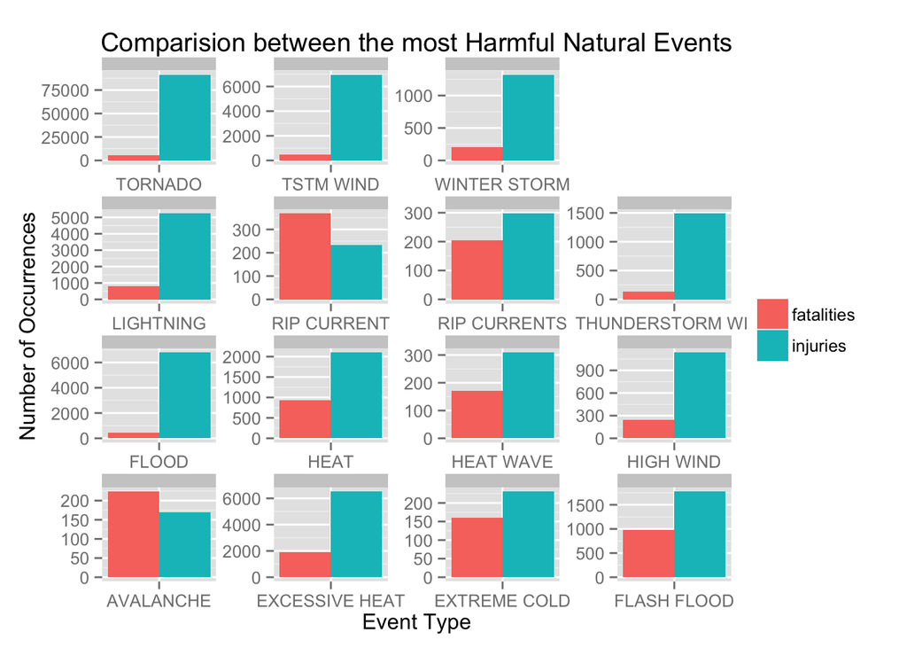

```r
joined_data <- left_join(sliced_fatalities, grouped_injuries, by="EVTYPE")
joined_data <- melt(joined_data, id="EVTYPE")
names(joined_data) <- c("event_type", "consequence", "total")

ggplot(joined_data, aes(event_type, total, fill=consequence)) +
    geom_bar(stat="identity", position="dodge") +
    facet_wrap(~event_type, scales="free", as.table=FALSE) +
    ylab("Number of Occurrences") +
    xlab("Event Type") +
    ggtitle("Comparision between the most Harmful Natural Events") +
    theme(legend.title=element_blank(), strip.text.x = element_blank())
```

As we can see in the plot, most of the events have a larger number of `INJURIES` than `FATALITIES`. The only exceptions are `AVALANCHE` and `RIP CURRENT`, I guess it’s because it doesn’t happen all the time, but when it occurs it’s more difficult to survive it.

Now, lets start the analysis of the impact in economics. We have two variables to deal with: `PROPDMG` and `CROPDMG`, the first one is about property damage and the second one about the crop damage. First we are going to group the damages by type of event and then sum the two kinds of damage to create a total damage.

```r
grouped_damage <- group_by(data, EVTYPE) %>%
    summarise(property_damage=sum(PROPDMG), crop_damage=sum(CROPDMG)) %>%
    mutate(totaldmg=property_damage + crop_damage) %>%
    arrange(desc(totaldmg))

total_damage <- sum(grouped_damage$totaldmg)

summary(grouped_damage)
```

```
##     EVTYPE          property_damage    crop_damage        totaldmg
##  Length:985         Min.   :      0   Min.   :     0   Min.   :      0
##  Class :character   1st Qu.:      0   1st Qu.:     0   1st Qu.:      0
##  Mode  :character   Median :      0   Median :     0   Median :      0
##                     Mean   :  11050   Mean   :  1399   Mean   :  12449
##                     3rd Qu.:     35   3rd Qu.:     0   3rd Qu.:     50
##                     Max.   :3212258   Max.   :579596   Max.   :3312277
```

As we can see, we don’t have any damage in almost 75% of the cases, but in total damage across the time we have a total cost of US$ 12262327.33. We are going to follow the same idea from the last analysis, so we are going to cut our data with the top 15 events.

Lets see what we got…

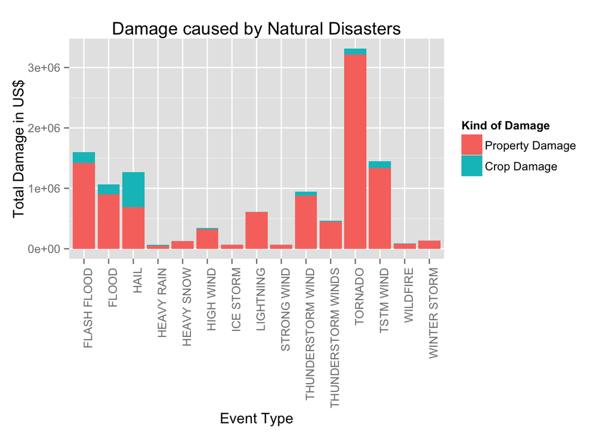

```r
sliced_damage <- slice(grouped_damage, 1:15) %>%
    select(EVTYPE, property_damage, crop_damage)
sliced_damage <- melt(sliced_damage, id="EVTYPE")
names(sliced_damage) <- c("event_type", "damage", "total")

sliced_damage_total <- sum(sliced_damage$total)

ggplot(sliced_damage, aes(event_type, total, fill=damage)) +
    geom_bar(stat="identity") +
    xlab("Event Type") +
    ylab("Total Damage in US$") +
    ggtitle("Damage caused by Natural Disasters") +
    scale_fill_discrete(name="Kind of Damage", labels=c("Property Damage", "Crop Damage")) +
    theme(axis.text.x = element_text(angle = 90, hjust = 1))
```

As we can see most of the expenditure with Natural Disasters comes from Property Damage and with our sliced data we had a total cost of US$ 11592802.95, which represents 95% from the original data.